# W01 — Od potrzeby informacyjnej do projektu badania

Zarządzanie informacją — część ilościowa — 2026/27

Marek Deja

2026/27

Wykład W01 otwiera część ilościową przedmiotu. Skrypt `analiza.R` zapisany w folderze wykładu tworzy tabele i wykresy wykładu W01: mapę kursu, słownik zbioru przykładowego i siedem wykresów z małymi przykładami liczbowymi. Kod skryptu pozostaje ukryty, a każdy wykres ma w tekście słowny opis osi, wartości i wniosku.

# Od sygnału problemu do pytania badawczego

Do biblioteki napływają wiadomości, że w nowym katalogu trudno znaleźć dokument. Jednocześnie liczba wizyt w katalogu rośnie. Zespół proponuje trzy rozwiązania: zmienić nazwy filtrów, nagrać instrukcję albo przeprowadzić szkolenie. Każda propozycja zakłada inną przyczynę trudności: nazwy filtrów są własnością interfejsu, znajomość procedury jest własnością użytkownika, a szkolenie ma zmienić sposób działania. Wzrost liczby wizyt jest zgodny z każdą z trzech diagnoz, więc wybór rozwiązania wymaga pomiaru, który rozdziela własności interfejsu, wiedzę użytkownika i sposób działania.

Przez cały kurs wracamy do problemu wyszukiwania w nowym katalogu. Zbiór przykładowy S02 — litera S z numerem oznacza scenariusz danych kursu — łączy ankietę wypełnianą po zadaniu wyszukiwawczym z obserwowanym czasem i powodzeniem zadania; zawiera 150 rekordów. Dane są syntetyczne: generator kursu tworzy odpowiedzi o znanej budowie, więc zbiór S02 służy do ćwiczenia analizy, a wiedza o rzeczywistej bibliotece wymaga danych z rzeczywistego badania. W projekcie indywidualnym oddzielisz plan rzeczywistego badania od analizy własnego zbioru dydaktycznego.

Pierwszym krokiem jest przełożenie zdania „trudno znaleźć” na zdarzenia możliwe do zaobserwowania. Czy użytkownik odnajduje rekord? Czy na podstawie rekordu wskazuje lokalizację dokumentu? Czy ocenia przydatność publikacji według podanych kryteriów? Trzy zdarzenia wymagają trzech różnych zadań, trzech definicji sukcesu i trzech różnych działań biblioteki. Statystyka zaczyna się od rozróżnienia rodzajów trudności, zanim pojawi się pierwszy wzór.

## Mapa kursu

Kurs składa się z pięciu wykładów o kodach W01–W05 i dziesięciu ćwiczeń o kodach C01–C10. Zadanie oddawane po ćwiczeniu ma kod Z z tym samym numerem, np. zadanie Z01 należy do ćwiczenia C01. Tabela „Mapa kursu” podaje kod, rodzaj, tytuł i treść każdej jednostki; odwołania do innych jednostek w tym wykładzie podają kod i tytuł z tej tabeli.

Mapa kursu: kod, rodzaj, tytuł i treść jednostek

| Kod | Rodzaj | Tytuł | Treść |
| --- | --- | --- | --- |
| W01 | wykład | Od potrzeby informacyjnej do projektu badania | Konstrukt, wskaźnik, skala pomiaru, populacja i próba, rodzaje projektów, estymanda i hipoteza. |
| W02 | wykład | Język danych, pomiar i opis | Rozkład, miary położenia i rozproszenia, wykresy rozkładu, indeks z pozycji ankiety, trafność i rzetelność. |
| W03 | wykład | Losowość, estymacja i dwa tory wnioskowania | Rozkłady prawdopodobieństwa, błąd standardowy, przedział ufności, test t, wartość p, bootstrap i permutacje. |
| W04 | wykład | Porównania grup i zależności kategorii | Porównanie dwóch średnich, pary pomiarów, rangi, wiele grup, tabela krzyżowa i test chi-kwadrat. |
| W05 | wykład | Korelacja, regresja i raport ilościowy | Korelacja, prosta regresja, reszty, przedział predykcji, kalibracja samooceny i akapit wyniku. |
| C01 | ćwiczenie | Od rekordu do wyniku: RStudio i własna przestrzeń pracy | Odczyt wiersza, kolumny, braku i mianownika w małej tabeli; pierwsza średnia, mediana i odsetek. |
| C02 | ćwiczenie | Surowy eksport: braki, duplikaty i jawne czyszczenie | Import pliku CSV, duplikaty, kod braku 99, czas spoza zakresu i dziennik reguł przygotowania danych. |
| C03 | ćwiczenie | Portret próby: czas wyszukiwania, skuteczność i zróżnicowanie | Średnia, mediana, SD, kwartyle, histogram i dystrybuanta czasu oraz odsetek powodzeń w grupach. |
| C04 | ćwiczenie | Od pozycji do konstruktu: samoocena i wykonanie zadania | Treść sześciu pozycji ankiety, odwrócenie pozycji 3, reguła indeksu i odsetki pytania wielokrotnego wyboru. |
| C05 | ćwiczenie | Niepewność estymaty: przedział, bootstrap i test jednej próby | Błąd standardowy, przedział ufności, test t jednej średniej, bootstrap i test zmiany znaków. |
| C06 | ćwiczenie | Dwie grupy: różnica czasu lub samooceny i tasowanie etykiet | Test Welcha, przedział różnicy średnich, g Hedgesa, bootstrap w grupach i test permutacyjny. |
| C07 | ćwiczenie | Kategorie i zachowanie: tabela, chi-kwadrat i Monte Carlo | Tabela 2 × 2, liczebności oczekiwane, test chi-kwadrat, Monte Carlo, różnica proporcji i V Craméra. |
| C08 | ćwiczenie | Samoocena a wykonanie: korelacja, permutacja i prosta regresja | Korelacja Pearsona i Spearmana, test permutacyjny, bootstrap par, prosta regresja i predykcja. |
| C09 | ćwiczenie | Warsztat projektu: od scenariusza do dwóch małych analiz | Wybór scenariusza projektu, dwa pytania, estymandy, plan pomiaru i pierwszy opis własnego wariantu danych. |
| C10 | ćwiczenie | Od wyniku do raportu: interpretacja, ograniczenia i odtwarzalność | Dwie analizy własnego wariantu, wspólna interpretacja, rekomendacja i odtworzenie raportu. |

Wykład prowadzi do jednej umiejętności: wskazania informacji, dzięki której zdanie badawcze staje się sprawdzalne. Wykres „Sześć etapów rozumowania” układa kolejne etapy od góry do dołu: problem instytucji, konstrukt, wskaźnik, projekt i próba, estymanda oraz wniosek. Przy każdym etapie stoi pytanie, na które odpowiada badacz, zanim przejdzie do następnego etapu.

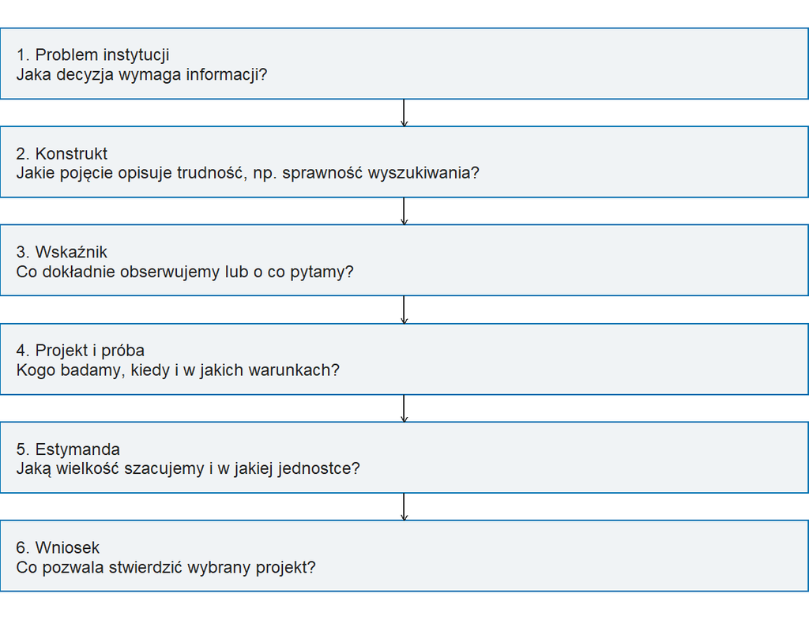

Sześć etapów rozumowania od problemu instytucji do wniosku, ułożonych od góry do dołu i połączonych strzałkami. Każdy etap zawiera pytanie do zapisania: od decyzji wymagającej informacji po zakres wniosku dozwolony przez projekt.

# Wkład nauki o informacji (LIS) w problem katalogu

Nauka o informacji i bibliotekoznawstwo (ang. *library and information science*, LIS) dostarcza pojęć porządkujących problem katalogu. Wilson opisuje zachowanie informacyjne jako szeroki obszar: obejmuje potrzebę informacyjną, poszukiwanie informacji w wielu źródłach i wyszukiwanie w konkretnym systemie. Dla katalogu wynika z modelu Wilsona rozróżnienie dwóch pytań: o korzystanie z katalogu i o całą drogę zdobywania informacji. Koniec sesji w katalogu jest zgodny z dwoma przebiegami — z niezaspokojoną potrzebą i z odpowiedzią uzyskaną od bibliotekarza — więc dziennik zdarzeń katalogu wymaga pytania o wynik całej drogi. [Wilson, 1999](https://www.informationr.net/tdw/publ/papers/1999JDoc.html).

Kuhlthau łączy proces poszukiwania z działaniami, myślami i odczuciami użytkownika. Model procesu poszukiwania Kuhlthau uzasadnia pytanie o moment pomiaru pewności: przed zadaniem, w trakcie albo po poznaniu wyniku. Ta sama odpowiedź na pytanie o pewność opisuje po sukcesie i przed rozpoczęciem pracy dwa różne momenty doświadczenia. W modelu Kuhlthau wzrost niepewności towarzyszy etapowi rozpoznawania tematu, więc pomiar pewności wymaga zapisu etapu procesu. [Kuhlthau, 1991](https://wp.comminfo.rutgers.edu/ckuhlthau2/wp-content/uploads/sites/185/2016/01/InsidetheSearchProcess.pdf).

Hargittai łączy dane ankietowe z obserwacją korzystania z sieci. Praca Hargittai uzasadnia rozdzielenie deklaracji „uważam, że potrafię” od obserwacji „wykonałem określone zadanie”. W kursie związek deklaracji i wykonania jest pytaniem empirycznym: ćwiczenie C08 (Samoocena a wykonanie) liczy korelację indeksu ankietowego z czasem zadania. [Hargittai, 2002](https://webuse.org/p/a09/).

Vial opisuje transformację cyfrową jako zmianę organizacyjną: technologia przekształca procesy, podział pracy i sposób tworzenia wartości instytucji. W przykładzie biblioteki instalacja katalogu jest zdarzeniem technicznym, a zmiana sposobu uzyskiwania pomocy, podziału pracy i dostępności zasobów ma własne wskaźniki. [Vial, 2019](https://doi.org/10.1016/j.jsis.2019.01.003).

Prace Wilsona, Kuhlthau, Hargittai i Viala dostarczają pojęć i uzasadnień pytań badawczych; dane S02 pochodzą z generatora kursu. Na podstawie literatury budujemy własne pytania: kto napotyka barierę, w którym momencie, jak barierę rozpoznajemy i co mogłoby pomóc. Trafność sześciu pozycji ankiety S02 wymaga własnego dowodu: analizy treści pozycji, spójności odpowiedzi i związku z wykonaniem zadania.

# Od pojęcia do obserwacji

## Konstrukt, wskaźnik i reguła kodowania

Konstrukt jest pojęciem, o którym chcemy wnioskować: kompetencja informacyjna, pewność wyszukiwania albo postrzegana użyteczność. Wskaźnik to obserwowalna informacja powiązana z konstruktem. Czas odnalezienia rekordu jest wskaźnikiem sprawności w konkretnym zadaniu i łączy kompetencję z innymi przyczynami tempa pracy, na przykład z dokładnym sprawdzaniem autorstwa i aktualności źródła.

Operacjonalizacja określa przejście od pojęcia do danych. Dla czasu zapisujemy moment rozpoczęcia, moment zakończenia, jednostkę, warunek przerwania i sposób zapisu niepowodzenia. Dla oceny źródła określamy kryteria poprawności. Dla samooceny zapisujemy dokładne brzmienie pytania, okres odniesienia i kategorie odpowiedzi. Zmiana momentu rozpoczęcia, momentu zakończenia, jednostki, warunku przerwania, brzmienia pytania lub kategorii odpowiedzi zmienia znaczenie wyniku.

| Pojęcie | Możliwy wskaźnik | Pytanie wymagające dodatkowego pomiaru |
| --- | --- | --- |
| Sprawność wyszukiwania | Czas wykonania określonego zadania | Czy znaleziono wiarygodne źródło? |
| Skuteczność | Poprawne odnalezienie wskazanego dokumentu: 0/1 | Czy użytkownik powtórzy sukces w innym zadaniu? |
| Samoocena umiejętności | Odpowiedź „potrafię dobrać słowa kluczowe” | Czy zadeklarowana umiejętność występuje w działaniu? |
| Postrzegana użyteczność | Ocena zrozumiałości filtrów i komunikatów | Jaki udział w trudności mają system i użytkownik? |
| Weryfikowanie informacji | Sprawdzenie autora, daty i źródła w protokole | Czy użytkownik robi tak poza sytuacją obserwacji? |
| Dostęp do informacji | Skuteczne otwarcie pełnego tekstu | Czy tekst odpowiada potrzebie i został zrozumiany? |

## Słownik zbioru S02

Słownik danych nadaje kolumnom znaczenie. Tabela „Słownik zbioru S02” wymienia 15 kolumn surowego pliku: identyfikator odpowiedzi, grupę porównania, częstość korzystania z zasobu, obserwowany czas zadania w minutach, sześć pozycji ankiety, obserwowane powodzenie zadania oraz cztery kolumny kanałów kontaktu. Kolumna „Skala” podaje skalę pomiaru, a kolumna „Kodowanie” — znaczenie liczb.

Słownik zbioru S02: kolumna, opis, skala pomiaru i kodowanie

| Kolumna | Opis | Skala | Kodowanie |
| --- | --- | --- | --- |
| id_odpowiedzi | Identyfikator odpowiedzi; identyczne powtórzenie to duplikat | identyfikator | o001… |
| grupa | Grupa porównania | nominalna | nowi / doświadczeni |
| czestosc_korzystania | Częstość korzystania z zasobu | porządkowa | 1=nigdy; 2=rzadko; 3=czasami; 4=często; 5=bardzo często |
| czas_wyszukiwania | Obserwowany czas wykonania zadania wyszukiwawczego w minutach | ilorazowa | 0–120 minut; wartości poza zakresem wymagają oceny |
| pozycja_1 | Szybko znajduję pole wyszukiwania w katalogu. | porządkowa | 1–5: od 1 = zdecydowanie nie do 5 = zdecydowanie tak |
| pozycja_2 | Nazwy filtrów są dla mnie zrozumiałe. | porządkowa | 1–5: od 1 = zdecydowanie nie do 5 = zdecydowanie tak; 99 = brak odpowiedzi |
| pozycja_3 | Odczytanie rekordu wymaga ode mnie zgadywania. | porządkowa | 1–5: od 1 = zdecydowanie nie do 5 = zdecydowanie tak |
| pozycja_4 | Potrafię znaleźć lokalizację dokumentu. | porządkowa | 1–5: od 1 = zdecydowanie nie do 5 = zdecydowanie tak |
| pozycja_5 | Komunikaty katalogu pomagają mi poprawić zapytanie. | porządkowa | 1–5: od 1 = zdecydowanie nie do 5 = zdecydowanie tak |
| pozycja_6 | Katalog wspiera wykonanie mojego zadania. | porządkowa | 1–5: od 1 = zdecydowanie nie do 5 = zdecydowanie tak |
| powodzenie | Obserwowany wynik zadania: Czy udało się znaleźć wskazany dokument? | nominalna | 0=nie; 1=tak |
| kanal_1 | Wybrano kanał: strona WWW | nominalna | 0=nie wybrano; 1=wybrano |
| kanal_2 | Wybrano kanał: e-mail | nominalna | 0=nie wybrano; 1=wybrano |
| kanal_3 | Wybrano kanał: media społecznościowe | nominalna | 0=nie wybrano; 1=wybrano |
| kanal_4 | Wybrano kanał: kontakt bezpośredni | nominalna | 0=nie wybrano; 1=wybrano |

Czas i powodzenie pochodzą z obserwacji wykonania zadania, a sześć pozycji i częstość korzystania — z deklaracji uczestnika. Tabela „Sześć pozycji ankiety S02” podaje brzmienie pozycji. Pozycje dotyczą rozumienia filtrów, odczytania rekordu, lokalizacji dokumentu i pomocy komunikatów, a część pozycji opisuje własne działanie uczestnika. Pozycja 3 ma kierunek odwrotny: zgoda ze zdaniem „Odczytanie rekordu wymaga ode mnie zgadywania” oznacza niższą użyteczność katalogu.

Sześć pozycji ankiety S02: brzmienie i kierunek (1 = zdecydowanie nie, 5 = zdecydowanie tak)

| Pozycja | Brzmienie | Kierunek |
| --- | --- | --- |
| 1 | Szybko znajduję pole wyszukiwania w katalogu. | bez zmiany |
| 2 | Nazwy filtrów są dla mnie zrozumiałe. | bez zmiany |
| 3 | Odczytanie rekordu wymaga ode mnie zgadywania. | odwrócona: 6 − x |
| 4 | Potrafię znaleźć lokalizację dokumentu. | bez zmiany |
| 5 | Komunikaty katalogu pomagają mi poprawić zapytanie. | bez zmiany |
| 6 | Katalog wspiera wykonanie mojego zadania. | bez zmiany |

Wynik złożony z sześciu pozycji nazywamy **indeksem deklarowanej użyteczności katalogu**. Indeks jest dydaktycznym wynikiem złożonym: łączy ocenę katalogu z oceną własnego radzenia sobie z katalogiem. Trafność indeksu wymaga dowodu z treści pozycji i ze związku z wykonaniem zadania. Kolumnę `indeks` tworzy skrypt przygotowania danych według reguły:

$$I_i=\frac{1}{m_i}\sum_{k\in O_i}x^{*}_{ik},
\qquad
x^{*}_{ik}=
\begin{cases}
6-x_{i3}, & k=3,\\
x_{ik}, & k\neq 3,
\end{cases}
\qquad \text{gdy } m_i\geq 5.$$

Czytamy: „indeks osoby $i$ to średnia jej ważnych odpowiedzi po odwróceniu pozycji 3, liczona dla osoby z co najmniej pięcioma ważnymi odpowiedziami”. Symbol $x_{ik}$ oznacza odpowiedź osoby $i$ na pozycję $k$ w skali 1–5, gwiazdka oznacza odpowiedź po ujednoliceniu kierunku, $O_i$ to zbiór pozycji z ważną odpowiedzią osoby, a $m_i$ liczba tych pozycji. Osoba z odpowiedziami 4, 4, 2, 5, 3, 4 ma po odwróceniu pozycji 3 wartości 4, 4, 4, 5, 3, 4, więc jej indeks wynosi $24/6=4{,}0$ punktu. Ćwiczenie C04 (Od pozycji do konstruktu) omawia regułę pięciu z sześciu pozycji i jej skutki.

## Jednostka analizy: osoba, zadanie i wiersz tabeli

W tabeli podstawowej jednostką analizy jest osoba wykonująca jedno zadanie. W dzienniku zdarzeń systemu (logu) jednostką rekordu jest pojedyncze zdarzenie: otwarcie strony, zapytanie lub kliknięcie filtra. Sto zdarzeń zapisanych dla jednej osoby to sto rekordów jednej jednostki analizy; w porównaniu osób ta osoba wnosi jedną obserwację.

Rozważ trzy osoby, z których każda wykonuje cztery zadania. Powstaje dwanaście rekordów wykonania i trzy osoby. Powtarzane pomiary tej samej osoby są zależne: dzielą jej doświadczenie, urządzenie i sposób pracy. Błąd standardowy średniej, czyli miara precyzji średniej omawiana szczegółowo na wykładzie W03 (Losowość, estymacja i dwa tory wnioskowania), zależy od liczby niezależnych jednostek $n$:

$$SE(\bar{x})=\frac{s}{\sqrt{n}},
\qquad
\frac{SE_{n=12}}{SE_{n=3}}=\frac{\sqrt{3}}{\sqrt{12}}=0{,}5 .$$

Symbol $s$ oznacza odchylenie standardowe pomiarów, a $n$ liczbę niezależnych jednostek. Potraktowanie dwunastu rekordów trzech osób jako dwunastu osób zmniejsza błąd standardowy o połowę, choć informacja pochodzi nadal od trzech osób. Analiza w kursie używa więc jednego wyniku na osobę albo analizy różnic w parach. Dla pomiaru tej samej osoby przed zmianą i po zmianie różnica w parze ma postać

$$d_i=x_{i,\mathrm{po}}-x_{i,\mathrm{przed}},
\qquad
\bar{d}=\frac{1}{n}\sum_{i=1}^{n}d_i ,$$

gdzie $x_{i,\mathrm{przed}}$ i $x_{i,\mathrm{po}}$ to dwa pomiary osoby $i$, a $\bar{d}$ średnia zmiana. Osoba z czasem 12 minut przed zmianą i 9 minut po zmianie ma $d_i=-3$ minuty.

Identyfikator służy połączeniu ankiety z obserwacją. Identyfikator jest etykietą nominalną: dopuszcza wyłącznie sprawdzenie, czy dwie wartości są równe. Powtórzony identyfikator wymaga wyjaśnienia: oznacza duplikat eksportu, drugie zadanie tej samej osoby albo błąd połączenia.

# Skala pomiaru i dozwolone działania

Skala pomiaru opisuje znaczenie relacji między wartościami. Klasa danych w R opisuje techniczny zapis: `numeric` przechowuje liczby, `character` tekst, `factor` kategorie z listą poziomów, a `logical` wartości prawda i fałsz. Skala pomiaru wyznacza dozwolone działania: kody 1 i 2 dla dwóch typów urządzeń pozwalają sprawdzić równość i policzyć częstości, a minuty pozwalają odejmować i dzielić.

| Skala | Przykład ZI | Sensowne pytanie | Dozwolone działania |
| --- | --- | --- | --- |
| Nominalna | Wybrany kanał pomocy | Ile osób wybrało każdy kanał? | $=$, $\neq$, liczebności |
| Porządkowa | „Nigdy” do „bardzo często” | Która odpowiedź jest wyżej w porządku? | $=$, $<$, $>$, mediana |
| Przedziałowa | Temperatura urządzenia w stopniach Celsjusza | O ile stopni różnią się pomiary? | $+$, $-$, średnia |
| Ilorazowa | Czas w minutach | O ile minut i ile razy dłużej trwało zadanie? | $+$, $-$, $\times$, $\div$ |

Kody 1–5 pojedynczej pozycji ankiety ustalają porządek odpowiedzi; odległości między kategoriami pozostają nieznane, bo przejście od „raczej nie” do środka skali i przejście od „raczej tak” do „zdecydowanie tak” mogą odpowiadać różnym zmianom odczucia. Ćwiczenie C04 (Od pozycji do konstruktu) omawia założenia uśredniania pozycji w wyniku złożonym.

Zmienna 0/1 ma szczególną własność: jej średnia jest proporcją jedynek. Suma kodów 0/1 równa się liczbie sukcesów $k$, więc

$$\hat{\pi}=\frac{1}{n}\sum_{i=1}^{n}y_i=\frac{k}{n},$$

gdzie $y_i$ oznacza wynik osoby $i$ (1 — sukces, 0 — niepowodzenie), $n$ liczbę osób ze znanym wynikiem, a $\hat{\pi}$ oszacowanie proporcji sukcesów. Sześć sukcesów w dziesięciu obserwacjach daje $\hat{\pi}=6/10=0{,}6$, czyli 60%. Równość średniej i proporcji wynika z kodowania 0/1 i dotyczy wyłącznie kodowania 0/1.

Wartość NA w zmiennej 0/1 oznacza nieznany wynik: osoba mogła odnieść sukces albo porażkę. Przypisanie zera zamienia pytanie o odsetek sukcesów wśród osób z zarejestrowanym wynikiem na pytanie z założeniem, że każda nieznana próba była porażką. Przy sześciu sukcesach wśród ośmiu znanych wyników i dwóch brakach odsetek wynosi $6/8=0{,}75$; po zamianie braków na zera wynosi $6/10=0{,}60$. Ćwiczenie C02 (Surowy eksport) omawia reguły kodowania braków, duplikatów i wartości spoza zakresu.

# Populacja, próba i zakres odpowiedzi

Populacja jest zbiorem jednostek, o którym chcemy mówić. Określenie „użytkownicy biblioteki” jest za szerokie dla danych od osób obecnych w czytelni w poniedziałek rano. Definicja populacji rozstrzyga, czy obejmuje ona użytkowników zdalnych, nowych, nieaktywnych, korzystających z telefonu i osoby, które po pierwszej trudności zrezygnowały. Włączenie lub wyłączenie użytkowników zdalnych, nowych, nieaktywnych, mobilnych i osób, które zrezygnowały, zmienia odpowiedź.

Rama doboru to praktyczna lista lub procedura, dzięki której docieramy do jednostek. Lista aktywnych kont obejmuje wyłącznie osoby z kontem, a ogłoszenie w katalogu dociera wyłącznie do osób odwiedzających katalog. Różnica między populacją a ramą doboru to błąd pokrycia. Większa liczba odpowiedzi z tego samego kanału zwiększa precyzję oszacowania dla ramy i pozostawia błąd pokrycia bez zmian.

Próba to osoby rzeczywiście objęte pomiarem. W przykładzie zaproszono 300 osób, 180 rozpoczęło zadanie, 150 ukończyło ankietę, a 142 ma ważny indeks. Każda liczba opisuje inny etap, więc każda analiza podaje N swojego etapu. Odsetek przejścia z nazwanym mianownikiem ma postać

$$p=\frac{\text{liczba osób na etapie}}{\text{liczba osób w mianowniku}} ,$$

a dla kolejnych etapów wynosi $180/300=0{,}60$, $150/180=0{,}83$ i $142/150=0{,}95$; od zaproszenia do ważnego indeksu przechodzi $142/300=0{,}47$ zaproszonych. Wykres „Przepływ próby” przedstawia cztery etapy.

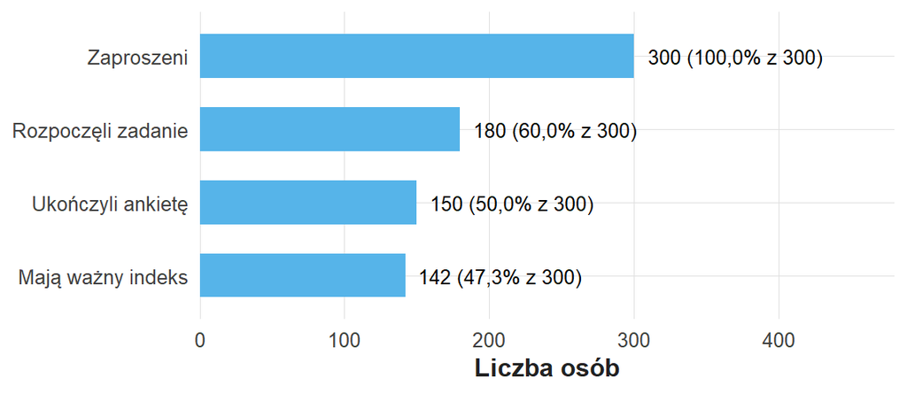

Przepływ próby od zaproszenia do ważnego indeksu. Oś pozioma: liczba osób; oś pionowa: cztery etapy. Liczba osób spada z 300 do 142 (47,3% zaproszonych); największy ubytek, 120 osób, następuje między zaproszeniem a rozpoczęciem zadania.

Dobór losowy nadaje każdej jednostce ramy znane prawdopodobieństwo wyboru i przez to daje podstawę wnioskowania o populacji objętej ramą; błąd pomiaru i odmowy udziału wymagają osobnej kontroli. Dobór wygodny służy wstępnemu rozpoznaniu problemu, a zakres uogólnienia wniosku z doboru wygodnego ogranicza się do opisanej grupy. Sformułowanie „w badanej próbie” informuje o zakresie dowodu.

# Trzy projekty, trzy różne odpowiedzi

## Opis istniejącego korzystania

Rekrutujemy nowych użytkowników i obserwujemy jedno zadanie. Szacujemy średni lub medianowy czas oraz odsetek powodzeń i wskazujemy etap, na którym pojawia się trudność. Pytanie o skutek instrukcji wymaga porównania z warunkiem przydzielonym części osób; projekt opisowy dostarcza stanu wyjściowego porównania z instrukcją.

Projekt opisowy jest właściwy, gdy instytucja zna problem, a skala problemu pozostaje nieznana. Odsetek niepowodzeń z przedziałem niepewności jest pełnoprawnym wynikiem statystycznym. Dobrze zdefiniowany odsetek niepowodzeń daje instytucji więcej niż test hipotezy dobrany bez związku z decyzją.

## Porównanie grup obserwacyjnych

Porównujemy osoby nowe i doświadczone. Różnica czasu opisuje związek grupy z wynikiem. Doświadczenie powstało poza kontrolą badacza, więc różnica czasu łączy działanie doświadczenia z działaniem cech współwystępujących: znajomości dziedziny, częstości korzystania i podobieństwa zadań zawodowych.

Wynik porównania obserwacyjnego uzasadnia sprawdzenie pomocy dla nowych użytkowników. Poprawna rekomendacja brzmi: „warto przetestować pomoc dla nowych użytkowników”. Oszacowanie skrócenia czasu przez szkolenie wymaga eksperymentu.

## Eksperyment z instrukcją

Wśród zgłoszonych osób losowo przydzielamy krótką instrukcję albo standardowy start. Obie grupy wykonują to samo zadanie w podobnych warunkach. Losowy przydział ogranicza systematyczne różnice między grupami przed interwencją i daje silniejszą podstawę do interpretacji różnicy jako skutku udostępnienia instrukcji.

Interwencją jest udostępnienie instrukcji, a obejrzenie filmu jest decyzją uczestnika. Porównanie według przydziału (ang. *intention-to-treat*) odpowiada na pytanie o skutek udostępnienia instrukcji. Porównanie osób, które obejrzały film, łączy działanie instrukcji z motywacją uczestników. Kurs rozpoznaje dwa pytania; metody dla porównań według faktycznego obejrzenia należą do metod zaawansowanych.

| Własność | Losowy dobór osób | Losowy przydział warunku |
| --- | --- | --- |
| Co losujemy? | Kto wejdzie do próby | Kto otrzyma daną wersję pomocy |
| Główna rola | Podstawa uogólnienia | Podstawa porównania przyczynowego |
| Co wnosi drugie losowanie? | Losowy przydział: podstawę wniosku przyczynowego | Losowy dobór: podstawę uogólnienia na populację |
| Możliwe połączenie | Losowa próba i losowy przydział w tej próbie | Ten sam projekt może zawierać oba losowania |

Badanie tych samych osób przed zmianą i po zmianie wnosi inny dowód. Skrócenie czasu wynika z instrukcji albo z przećwiczenia zadania. Rozdzielenie działania instrukcji od efektu wprawy wymaga grupy porównawczej i kontroli kolejności zadań. Pomiary przed i po tworzą pary, więc analiza porównuje różnice w parach $d_i$.

## Wdrożenie zmiany bez losowego przydziału

Biblioteka wprowadza nowe filtry najpierw w filii A, a miesiąc później w filii B. Kolejność wdrożenia wynika z decyzji biblioteki, a badacz mierzy średni czas przed zmianą i po zmianie w obu filiach. Plan quasi-eksperymentalny szuka skutku interwencji bez randomizacji, czyli bez losowego przydziału filii, i wykorzystuje uzasadnione porównanie.

W hipotetycznej filii A średni czas spadł z 10 do 7 minut, a w filii B, bez nowych filtrów, z 8 do 7 minut. Różnica zmian odejmuje zmianę wspólną dla obu filii:

$$\widehat{DiD}=(\bar{y}_{A,\mathrm{po}}-\bar{y}_{A,\mathrm{przed}})-(\bar{y}_{B,\mathrm{po}}-\bar{y}_{B,\mathrm{przed}})=(7-10)-(7-8)=-2 \text{ minuty}.$$

Symbol $\bar{y}_{A,\mathrm{przed}}$ oznacza średni czas w filii A przed wdrożeniem, a pozostałe symbole — odpowiednie średnie po wdrożeniu i w filii B. Wykres „Różnica zmian w dwóch filiach” przedstawia oba przebiegi i przebieg filii A przy zmianie takiej jak w filii B.

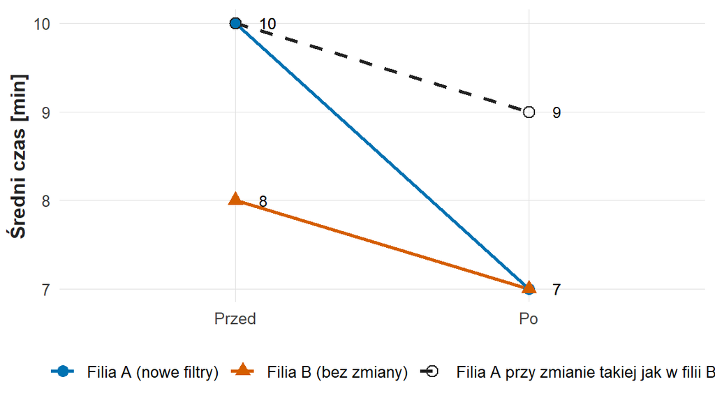

Różnica zmian w dwóch filiach. Oś pozioma: pomiar przed i po wdrożeniu; oś pionowa: średni czas w minutach. Filia A (koła) spada z 10 do 7 minut, filia B (trójkąty) z 8 do 7 minut; linia przerywana przedstawia przebieg filii A przy spadku o 1 minutę, jak w filii B, i kończy się przy 9 minutach, 2 minuty powyżej obserwowanego wyniku filii A.

Interpretacja przyczynowa wyniku −2 minuty wymaga założenia trendów równoległych: bez wdrożenia czas w obu filiach zmieniałby się tak samo. Wymaga też wykluczenia równoczesnego szkolenia w filii A, zmiany zadań i zmiany składu badanych. Dwa pomiary w filii dają jeden odcinek trendu, a sprawdzenie historii trendów wymaga pomiarów z kilku wcześniejszych okresów. Rachunek różnicy zmian ilustruje logikę planu quasi-eksperymentalnego i należy do rozszerzeń kursu.

Eksperyment naturalny wykorzystuje zmianę pochodzącą spoza decyzji badacza. Ekspozycja to warunek, któremu podlega jednostka, np. dostęp do zdalnego katalogu. Przykładem do rozważenia jest administracyjny harmonogram uruchamiania zdalnego dostępu, niezwiązany z dotychczasowymi umiejętnościami użytkowników. Wartość eksperymentu naturalnego zależy od mechanizmu przydziału ekspozycji: przydział niezwiązany z cechami użytkowników i wiarygodna grupa porównawcza uzasadniają porównanie. Rozróżnienie projektów opiera się na sposobie powstawania ekspozycji i na możliwości porównania. [de Vocht i współautorzy, omówienie projektów naturalnych i quasi-eksperymentalnych](https://arxiv.org/abs/2008.02509).

## Piramida dowodów: wskazówka zależna od pytania

Uproszczona piramida dowodów o skutkach interwencji układa projekty według zdolności wykluczania wyjaśnień alternatywnych. Od podstawy piramida obejmuje opinię eksperta, opis pojedynczego przypadku, badanie porównawcze bez randomizacji, badanie z randomizacją oraz przegląd systematyczny z metaanalizą. Wykres „Piramida dowodów” przedstawia pięć poziomów w kolejności od podstawy.

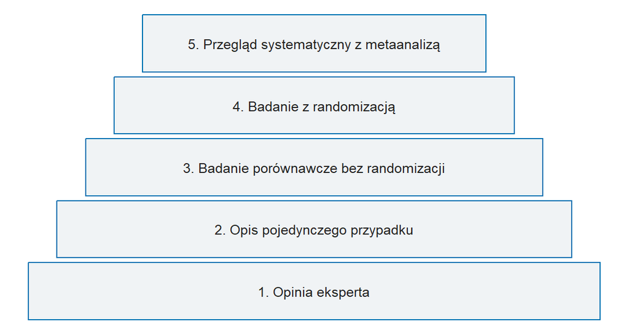

Uproszczona piramida dowodów o skutkach interwencji. Pięć poziomów od podstawy do wierzchołka: opinia eksperta, opis pojedynczego przypadku, badanie porównawcze bez randomizacji, badanie z randomizacją, przegląd systematyczny z metaanalizą; każdy wyższy poziom jest węższy.

Piramida pomaga szukać badań ograniczających wyjaśnienia alternatywne. Ocena konkretnej publikacji uwzględnia dodatkowo jakość pomiaru, pełność raportowania i dopasowanie populacji: wadliwe pomiary, selektywne raportowanie lub inna populacja osłabiają także badanie randomizowane.

Przegląd systematyczny stosuje jawną procedurę wyszukiwania i oceny badań. Metaanaliza należy do przeglądów, w których badania mierzą porównywalny wynik, i łączy ich oszacowania średnią ważoną:

$$\hat{\theta}=\frac{\sum_{j} w_j\hat{\theta}_j}{\sum_{j} w_j},
\qquad
w_j=\frac{1}{SE_j^{2}},$$

gdzie $\hat{\theta}_j$ to oszacowanie z badania $j$, a $w_j$ jego waga, większa dla badań precyzyjnych. Gdy każde badanie zawyża wynik o to samo obciążenie $b$, średnia ważona też zawyża wynik o $b$: łączenie badań zwiększa precyzję i zachowuje wspólne obciążenie. Wytyczne Oxford Centre for Evidence-Based Medicine (OCEBM) wiążą hierarchię z pytaniem i odróżniają poziom projektu od końcowej oceny dowodu. Rama OCEBM powstała w medycynie; zastosowanie w LIS wymaga dopasowania poziomów do pytań o usługi informacyjne. [OCEBM: wprowadzenie do poziomów dowodów](https://www.cebm.ox.ac.uk/resources/levels-of-evidence/levels-of-evidence-introductory-document).

Pytanie biblioteki „jaka część obecnych użytkowników napotyka barierę?” wymaga aktualnego, dobrze dobranego pomiaru lokalnego. Eksperyment z instrukcją odpowiada na pytanie o skutek udostępnienia pomocy. Dobry dowód to wynik właściwego projektu dla konkretnego pytania, z rozpoznanymi ograniczeniami.

# Jaka wielkość ma odpowiedzieć na pytanie

## Estymanda, parametr, estymator i estymata

Tabela „Symbole wykładu W01” zbiera oznaczenia wzorów wykładu W01. Wymowa pomaga czytać wzór na głos, a jednostka przypomina, w czym wyrażony jest wynik.

| Symbol | Wymowa | Znaczenie | Jednostka |
| --- | --- | --- | --- |
| $\mu$ | mi | średnia w populacji | minuty |
| $\mu_N$, $\mu_D$ | mi en, mi de | średnia populacyjna nowych (N) i doświadczonych (D) użytkowników | minuty |
| $\Delta$ | delta | różnica średnich populacyjnych $\mu_N-\mu_D$ | minuty |
| $\widehat{\Delta}$ | delta z daszkiem | oszacowanie różnicy z próby | minuty |
| $\bar{x}_N$, $\bar{x}_D$ | iks z kreską | średnie w próbie | minuty |
| $n_N$, $n_D$ | en | liczby osób z ważnym czasem w grupach | osoby |
| $x_{Ni}$, $x_{Di}$ | iks en i, iks de i | czas $i$-tej osoby w grupie nowych lub doświadczonych | minuty |
| $\pi$, $\hat{\pi}$ | pi, pi z daszkiem | proporcja sukcesów w populacji i jej oszacowanie | ułamek |
| $\rho_S$, $r_S$ | ro es, er es | korelacja rang w populacji i w próbie | liczba od −1 do 1 |
| $SE$ | es e | błąd standardowy, miara precyzji estymatora | jednostka estymatora |
| $H_0$, $H_1$ | ha zero, ha jeden | hipoteza zerowa i alternatywna o parametrze | — |

**Estymanda** jest dokładnie określoną wielkością, którą chcemy oszacować. Przykład: różnica średniego czasu między nowymi a doświadczonymi użytkownikami w określonej populacji, dla wspólnego zadania i procedury. Definicja estymandy obejmuje grupy, wynik, sposób podsumowania i warunki pomiaru. Wyrażenie „wpływ katalogu” staje się estymandą po dopisaniu grup, wyniku, podsumowania i warunków pomiaru.

**Parametr** jest liczbową cechą przyjętego modelu lub populacji, np. średnią $\mu$. Estymanda może być pojedynczym parametrem albo funkcją kilku parametrów, np. różnicą $\Delta=\mu_N-\mu_D$. Cztery terminy nazywają role w rozumowaniu: estymanda to cel, parametr to liczba w populacji lub modelu, estymator to reguła obliczenia, estymata to wynik reguły.

**Estymator** jest regułą obliczania wyniku z próby. Średnia arytmetyczna jest estymatorem średniej populacyjnej przy odpowiednich założeniach. **Estymata** jest otrzymaną liczbą, np. 8,4 minuty. Inna próba daje zwykle inną estymatę, choć pytanie i reguła obliczania pozostają te same.

| Pytanie | Estymanda | Estymator | Przykładowa estymata |
| --- | --- | --- | --- |
| Jak długo trwa zadanie? | Średni czas $\mu$ | Średnia $\bar{x}$ | 8,4 min |
| Jaka część osób odnosi sukces? | Proporcja $\pi$ | Udział jedynek $\hat{\pi}$ | 0,72 |
| O ile różnią się grupy? | $\Delta=\mu_N-\mu_D$ | $\bar{x}_N-\bar{x}_D$ | 1,8 min |
| Czy deklaracja i czas współzmieniają się monotonicznie? | Korelacja rang $\rho_S$ | Korelacja rang w próbie $r_S$ | $-0{,}32$ |

Liczby w ostatniej kolumnie są przykładami spoza zbioru S02 i ustalają jednostki wyników: minuty dla średniej i różnicy, ułamek dla proporcji, liczba bez jednostki dla korelacji rang. Korelacja rang przyjmuje wartości od −1 do 1; znak ujemny oznacza, że wyższej deklaracji towarzyszy krótszy czas. Proporcję 0,72 odczytujemy jako 72% osób, a liczbę osób podaje licznik ułamka.

## Wzór, który da się powiedzieć po polsku

$$\widehat{\Delta}=\bar{x}_N-\bar{x}_D
=\frac{1}{n_N}\sum_{i=1}^{n_N}x_{Ni}
-\frac{1}{n_D}\sum_{i=1}^{n_D}x_{Di}.$$

Czytamy: „szacowana różnica to średni czas nowych użytkowników minus średni czas doświadczonych”. Kreska nad $x$ oznacza średnią w próbie. Daszek nad deltą sygnalizuje oszacowanie. Sigma $\sum$ poleca dodać wskazane wartości. Indeks $i$ numeruje osoby w grupie: od 1 do $n_N$ wśród nowych i od 1 do $n_D$ wśród doświadczonych.

Średnie 9 i 7 minut dają różnicę 2 minut. Dodatni znak oznacza, że nowi potrzebowali średnio więcej czasu. Zamiana kolejności grup daje $-2$ minuty i opisuje to samo zjawisko, więc zdanie o znaku różnicy nazywa kolejność grup: „nowi minus doświadczeni”.

Pierwsza kontrola wzoru dotyczy jednostki: wynik o czasie zachowuje jednostkę czasu. Po przeliczeniu minut na sekundy obie średnie i różnica rosną sześćdziesięciokrotnie, a sens porównania pozostaje ten sam. Statystyka testowa dzieli różnicę przez jej błąd standardowy:

$$t=\frac{\widehat{\Delta}}{SE(\widehat{\Delta})} .$$

Minuty w liczniku i w mianowniku skracają się, więc statystyka $t$ jest liczbą bez jednostki. Różnica 2 minuty przy błędzie standardowym 0,8 minuty daje $t=2/0{,}8=2{,}5$. Ćwiczenie C06 (Dwie grupy) liczy statystykę $t$ dla danych S02.

# Wybór estymandy zmienia odpowiedź

Wyobraź sobie czasy czterech osób: 2, 3, 3 i 20 minut. Średnia to suma podzielona przez liczbę pomiarów, $(2+3+3+20)/4=7$ minut. Mediana to środkowa wartość uporządkowanego zbioru; dla uporządkowanych wartości $x_{(1)}\leq\dots\leq x_{(n)}$

$$\tilde{x}=
\begin{cases}
x_{((n+1)/2)}, & n \text{ nieparzyste},\\[2pt]
\tfrac{1}{2}\left(x_{(n/2)}+x_{(n/2+1)}\right), & n \text{ parzyste}.
\end{cases}$$

Symbol $x_{(k)}$ oznacza $k$-tą wartość po uporządkowaniu rosnąco. Dla czterech czasów $n=4$ jest parzyste, więc mediana wynosi $(3+3)/2=3$ minuty. Wykres „Średnia i mediana czterech czasów” zestawia obie miary.

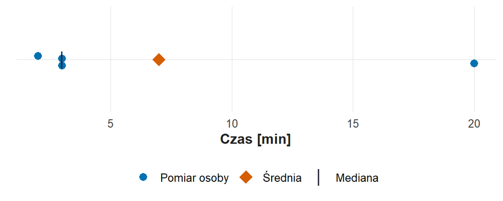

Średnia i mediana czterech czasów. Oś pozioma: czas w minutach. Trzy koła leżą przy 2 i 3 minutach, czwarte przy 20 minutach; kreska mediany leży w skupisku przy 3 minutach, a romb średniej przy 7 minutach, między skupiskiem a wartością 20 minut.

Zdanie „typowe zadanie trwa 7 minut” wprowadza w błąd czytelnika, który rozumie typowość jako środek uporządkowanej grupy. Średnia odpowiada jednak na użyteczne pytanie o przeciętny nakład czasu. Wybór miary wynika z pytania: średnia opisuje przeciętny nakład czasu, mediana czas osoby środkowej w uporządkowanej grupie.

Ograniczenie analizy do osób, które odniosły sukces, zmienia estymandę. Średni czas wszystkich prób i średni czas udanych prób to różne estymandy. Nowy interfejs, który pomaga osobom z trudnościami, zwiększa liczbę sukcesów i może wydłużyć średni czas wśród skutecznych użytkowników. Przykład: pięć osób odnosi sukces po 6 minutach; po zmianie do grupy skutecznych dołączają trzy osoby, które potrzebują 12 minut, więc średnia udanych prób rośnie do $(5\cdot 6+3\cdot 12)/8=8{,}25$ minuty. Wzrost średniego czasu wynika wtedy ze zmiany składu grupy skutecznych.

Dlatego w kursie czytamy czas razem z powodzeniem. Rzeczywiste badanie ustala ponadto limit czasu i sposób zapisu przerwanej próby. W przykładzie spoza zbioru S02 zadanie przerywa się po 10 minutach, a wartość „10 minut” zapisana przy przerwaniu jest dolną granicą czasu: osoba potrzebowałaby co najmniej 10 minut. Taki zapis nazywa się cenzurowaniem prawostronnym; pełna analiza czasu z cenzurowaniem należy do metod analizy czasu do zdarzenia, spoza zakresu kursu. W zbiorze S02 słownik podaje zakres czasu 0–120 minut.

Odsetek wśród osób obecnych w bibliotece ma w mianowniku osoby obecne, a odsetek wśród wszystkich potencjalnych użytkowników wymaga mianownika obejmującego osoby nieobecne. Mianownik należy do definicji pytania badawczego.

# Hipoteza, efekt i niepewność

Hipoteza badawcza wynika z problemu i uzasadnienia. Możemy przewidywać, że nowi użytkownicy potrzebują więcej czasu, bo słabiej znają strukturę rekordu; przewidywanie wymaga dopiero sprawdzenia. Hipoteza statystyczna przekłada przewidywanie na zdanie o parametrze: $H_0\colon \Delta = 0$ wobec $H_1\colon \Delta \neq 0$. Równość średnich dotyczy jednego parametru: rozkłady czasu w dwóch grupach mogą przy równych średnich różnić się rozrzutem i kształtem. Wykres „Dwa rozkłady o tej samej średniej” przedstawia dwa rozkłady czasu o średniej 8 minut i różnym rozrzucie.

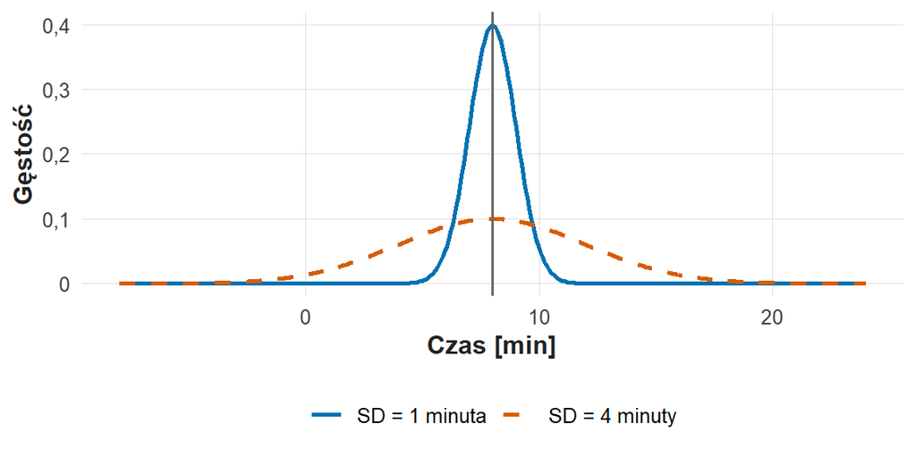

Dwa rozkłady czasu o tej samej średniej 8 minut. Oś pozioma: czas w minutach; oś pionowa: gęstość. Obie krzywe mają szczyt przy 8 minutach; krzywa ciągła (SD = 1 minuta) obejmuje głównie wartości od 6 do 10 minut, krzywa przerywana (SD = 4 minuty) — od 0 do 16 minut.

Efekt w kursie oznacza wielkość różnicy lub związku, czyli efekt statystyczny. Skutek interwencji (efekt przyczynowy) wymaga projektu z losowym przydziałem albo uzasadnionego planu quasi-eksperymentalnego. Różnica średnich w grupach obserwacyjnych jest miarą efektu statystycznego.

Precyzję estymaty opisuje przedział ufności, czyli zakres wartości parametru zgodnych z danymi przy przyjętych założeniach. Różnica 2 minut z przedziałem od 1,7 do 2,3 minuty ma inne znaczenie niż ta sama różnica z przedziałem od $-3$ do 7 minut. Drugi wynik jest zgodny z dużo szerszym zakresem wartości, w tym z różnicą ujemną. Wykres „Ta sama estymata, dwa przedziały” zestawia oba wyniki.

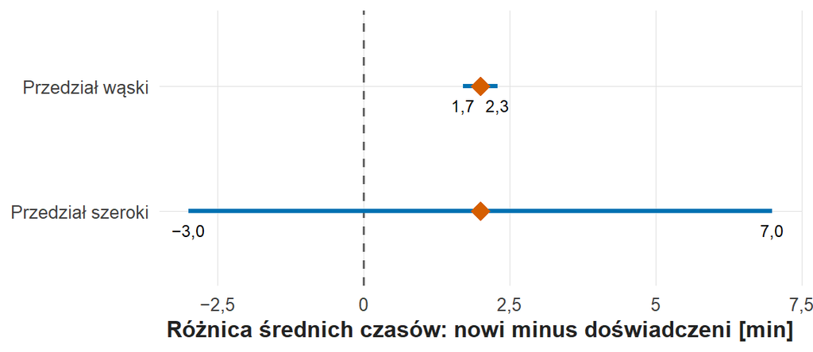

Ta sama estymata różnicy, dwa przedziały. Oś pozioma: różnica średnich czasów, nowi minus doświadczeni, w minutach; linia przerywana oznacza zero. Oba romby leżą przy 2 minutach; przedział wąski obejmuje wartości od 1,7 do 2,3 i leży w całości po dodatniej stronie zera, przedział szeroki obejmuje wartości od −3 do 7 i przecina zero.

Siła czasownika we wniosku odpowiada szerokości przedziału: przedział wąski uzasadnia zdanie „nowi potrzebowali średnio około 2 minut więcej”, a przedział szeroki — zdanie „dane są zgodne zarówno z krótszym, jak i z wyraźnie dłuższym czasem nowych”. Wykład W03 (Losowość, estymacja i dwa tory wnioskowania) wyjaśnia konstrukcję przedziału ufności i wartość p. Kolejność pracy pozostaje stała: najpierw ustalamy, co chcemy oszacować i w jakiej jednostce, potem jak niepewny jest wynik, a następnie co wolno z wyniku wywnioskować. Test statystyczny korzysta z populacji i pomiaru ustalonych w pierwszym kroku.

# Przykład prowadzony: od ogólnego postulatu do planu

Zespół biblioteki pisze: „Chcemy zbadać, czy kompetencje cyfrowe wpływają na skuteczność transformacji biblioteki”. Zdanie zawiera dwa szerokie pojęcia i deklarację wpływu. Zbiór S02 zawiera czas, powodzenie, częstość korzystania, sześć pozycji oceny katalogu i cztery kanały kontaktu; każda z tych zmiennych mierzy wąski fragment zdania zespołu.

Pierwsza dopuszczalna wersja pytania brzmi: „Jak różni się odsetek poprawnego odnalezienia wskazanego dokumentu między nowymi i doświadczonymi użytkownikami w obserwowanej próbie?”. Wynikiem jest powodzenie 0/1, grupą doświadczenie, a estymandą różnica proporcji. Zakres wniosku obejmuje obserwacyjne porównanie i pojedyncze zadanie.

Druga wersja brzmi: „Czy wyższej deklarowanej użyteczności katalogu towarzyszy krótszy czas wykonania zadania?”. Pytanie o związek wymaga pary wartości dla każdej osoby: indeksu i czasu. Estymandą jest współczynnik związku, np. korelacja rang. Ocena zebrana po zadaniu odzwierciedla częściowo przebieg zadania, co należy do interpretacji wyniku.

Trzecia wersja wymaga nowych danych: „Czy udostępnienie instrukcji filtrów zwiększa prawdopodobieństwo znalezienia dokumentu?”. Projektujemy losowy przydział instrukcji, wspólną definicję sukcesu i porównanie według przydziału. Eksperyment wymaga nowego zbierania danych z losowym przydziałem; zbiór S02 odpowiada na dwa pierwsze pytania.

## Ćwiczenie interpretacyjne z omówieniem

Rozważ zdanie: „Wśród osób, które wypełniły ankietę, 80% oceniło katalog dobrze, więc 80% studentów ma wysokie kompetencje informacyjne”. Wskaż dwa odrębne przeskoki rozumowania. Pierwszy dotyczy populacji: respondenci to osoby, które wypełniły ankietę, a zdanie mówi o wszystkich studentach. Drugi dotyczy pomiaru: pozytywna ocena katalogu jest opinią o systemie, a zdanie mówi o kompetencji.

Poprawione zdanie brzmi: „Wśród respondentów z ważną odpowiedzią 80% wybrało kategorię pozytywnej oceny katalogu”. Pełny raport dodaje brzmienie pytania, kategorie włączone do „pozytywnej” odpowiedzi oraz licznik i mianownik. Ostrożność polega na dopasowaniu treści zdania do danych.

Rozważ teraz: „Po szkoleniu średni czas spadł o 2 minuty”. Przy pomiarze tych samych osób wykonujących to samo zadanie wyjaśnieniem alternatywnym jest wprawa. Przy pomiarze innych osób przed szkoleniem i po szkoleniu dochodzi zmiana składu próby. Jedno zdanie liczbowe wymaga więc różnych zastrzeżeń zależnie od projektu.

# Generatywna SI: pomoc w rozumieniu pojęć i odpowiedzialność badacza za pomiar

W części ilościowej przedmiotu można korzystać z SI do wyjaśniania pojęć i pomocy przy błędzie kodu. Interpretację oraz wnioski piszesz samodzielnie. Korzystanie z SI jest dobrowolne i niezależne od zakładania konta w zewnętrznym narzędziu. Wygenerowany fragment oznaczasz przy miejscu użycia, a w raporcie opisujesz rzeczywisty zakres pomocy. Hasła, tokeny, dane osobowe i prace innych osób pozostają poza narzędziem SI. Odpowiedź modelu jest wskazówką, a źródłem naukowym są sprawdzone publikacje. Zasady kursu stosują [zarządzenie UJ nr 115/2025, §§3–4 i 6–7](https://bip.uj.edu.pl/documents/1384597/159749054/zarz_115_2025.pdf).

Rozważ dydaktyczną propozycję operacjonalizacji: „Kompetencję mierzymy pytaniem, czy podoba się nowa strona biblioteki”. Zdanie brzmi płynnie i zmienia konstrukt: odpowiedź mierzy ocenę strony. Poprawka polega na uzasadnieniu wskaźnika, np. oceny wiarygodności dwóch źródeł według jawnych kryteriów, i na wskazaniu aspektów kompetencji, które wymagają osobnego pomiaru.

Podobnie propozycja „zmierz czas od kliknięcia do sukcesu” obejmuje wyłącznie osoby, które odniosły sukces. Pomiar czasu zaczyna się od ustalenia limitu, warunku przerwania oraz zapisu niepowodzenia. Narzędzie pomaga zauważyć brak definicji, a odpowiedzialność za operacjonalizację pozostaje po stronie badacza. Krytyczną ocenę argumentacji liczbowej rozwija wykład W05 (Korelacja, regresja i raport ilościowy), a ćwiczenie C09 (Warsztat projektu) stosuje ją do planu projektu indywidualnego.

# Przygotowanie do ćwiczeń C01 i C02

Na ćwiczeniu C01 (Od rekordu do wyniku) otworzysz w RStudio własny plik ćwiczenia, poznasz rekord i odczytasz prosty wynik. Na ćwiczeniu C02 (Surowy eksport) prześledzisz, jak surowy eksport zmienia się w tabelę analityczną. Oba spotkania korzystają z czterech rozróżnień: osoba i rekord, konstrukt i wskaźnik, brak i niepowodzenie, populacja i próba.

Do własnej powtórki zapisz jedno pytanie o usługę informacyjną. Dodaj wynik, jednostkę analizy, populację i sposób pomiaru. Następnie dokończ zdanie: „Odpowiedzią liczbową byłaby…”. Gdy nazwanie wielkości odpowiadającej na pytanie sprawia trudność, doprecyzuj wynik, grupę i sposób podsumowania. Notatka służy powtórce; temat projektu indywidualnego wybierasz na ćwiczeniu C09.

Na końcu notatki dopisz informację wymagającą nowych danych: skutek instrukcji, zachowanie poza laboratorium, potrzebę osób korzystających z innych źródeł lub trwałość uczenia się. Dobrze określone ograniczenie wskazuje następne badanie.

# Literatura do dalszej pracy

- Wilson, T.D. (1999). *Models in information behaviour research*. Journal of Documentation, 55(3), 249–270. [Tekst autora](https://www.informationr.net/tdw/publ/papers/1999JDoc.html).
- Kuhlthau, C.C. (1991). *Inside the search process: Information seeking from the user’s perspective*. JASIS, 42(5), 361–371. [Tekst](https://wp.comminfo.rutgers.edu/ckuhlthau2/wp-content/uploads/sites/185/2016/01/InsidetheSearchProcess.pdf).
- Hargittai, E. (2002). *Beyond logs and surveys: In-depth measures of people’s web use skills*. JASIST, 53(14), 1239–1244. [Strona autorki](https://webuse.org/p/a09/), [DOI](https://doi.org/10.1002/asi.10166).
- Vial, G. (2019). *Understanding digital transformation: A review and a research agenda*. JSIS, 28(2), 118–144. [DOI](https://doi.org/10.1016/j.jsis.2019.01.003).

Przykłady liczbowe, zadania i proponowane projekty wykładu są dydaktyczne; wyniki cytowanych prac zawierają ich oryginalne publikacje.